# Gross Value Added

[figure not shown]

This script uses Gross Value Added data and revenue and profit for Tottenham Hotspur Football Club (THFC) to assess the GVA of the area 1km around Tottenham Hotspur Stadium (THS) with and without the club’s contribution to GVA.

We assume that the club’s GVA contribution can be approximated to be somewhere between its revenue and its profit before depreciation and exceptional items for a given year.

```python
import psycopg2
import configparser
import os
import requests
import pandas as pd
from sqlalchemy import create_engine
import matplotlib.pyplot as plt
from sqlalchemy import create_engine
import janitor
import matplotlib as mpl
import numpy as np
import pickle

# Load DB config
config = configparser.ConfigParser()
config.read(os.path.join('..', 'db_config.ini'))
db_params = dict(config['postgresql'])

# Build SQLAlchemy connection string
conn_str = (
    f"postgresql+psycopg2://{db_params['user']}:{db_params['password']}"
    f"@{db_params['host']}:{db_params['port']}/{db_params['database']}"
)

# Create engine
engine = create_engine(conn_str)

# Colours
with open(os.path.join('..', 'jk_primary_colours.txt'), 'r') as file:
    jk_colours = [line.strip() for line in file]

mpl.rcParams['font.family'] = 'Open Sans'
mpl.rcParams['font.size'] = 16

data_dir = os.path.join('..','data')
```

```python
query = 'https://www.nomisweb.co.uk/api/v01/dataset/NM_2400_1.data.csv?geography=1245708671...1245708705,1245714941&cell=0&measures=20100'

data_dir = os.path.join('..','data')
filepath = os.path.join(data_dir, 'gva_msoa_haringey.csv')
if not os.path.isfile(filepath):
    response = requests.get(query)
    with open(filepath, 'wb') as file:
        file.write(response.content)
else:
    print('Loading data')

gva_msoa = pd.read_csv(filepath)

gva_msoa = janitor.clean_names(gva_msoa)

gva_msoa = gva_msoa.rename(
    columns = {
        'date': 'year',
        'geography_code': 'msoa11cd',
        'obs_value': 'gva'

    }
)

gva_msoa = gva_msoa[['msoa11cd','year','gva']]
```

```
Loading data
```

Create a dataframe for THFC revenue and profit. These figures are taken from their annual reports: https://www.tottenhamhotspur.com/the-club/investor-relations/annual-reports/

```python
# these figures are taken from THS annual reports
ths_profit = pd.DataFrame({
    'year': [2010, 2011, 2012, 2013, 2014,2015,2016,2017,2018,2019,2020,2021,2022,2023],
    'ths_profit': [22674,32294,14195,10499,26440,34016,47327,81406,151979,147873,33785,20563,40061,61685],
    'ths_revenue': [119814,163486,144156,147392,180541,196377,209770,309674,380697, 460695,402386,361872,444028,549633],
    'ths_profit_before_exc': [25444,37578,23023,23393,36040,46746,63303,120916,162547,172732,115284,97084,112254,138663]
}
)

cols = ['ths_profit','ths_revenue','ths_profit_before_exc']
ths_profit[cols] = ths_profit[cols] / 1000
```

This shows THFC revenue and profit over time

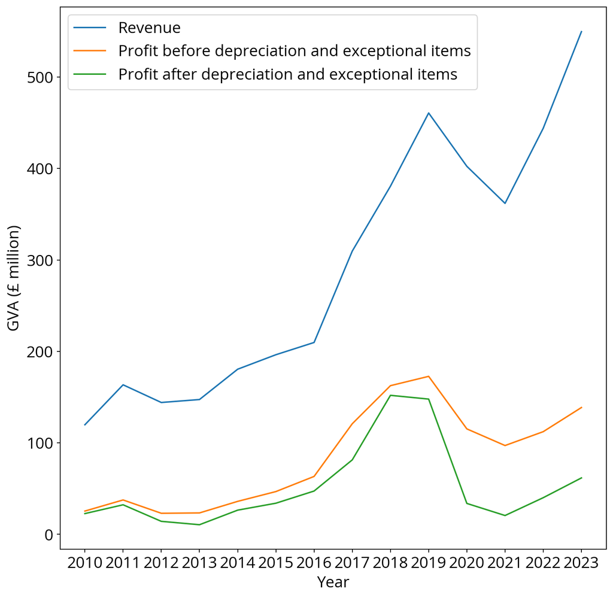

```python
fig, ax = plt.subplots(figsize=(10,10))

ax.plot(
    ths_profit['year'],
    ths_profit['ths_revenue'],
    label='Revenue'
)

ax.plot(
    ths_profit['year'],
    ths_profit['ths_profit_before_exc'],
    label='Profit before depreciation and exceptional items'
)

ax.plot(
    ths_profit['year'],
    ths_profit['ths_profit'],
    label='Profit after depreciation and exceptional items'
)

ax.set_ylabel('GVA (£ million)')
ax.set_xlabel('Year')

ax.legend()
ax.set_xticks(np.arange(2010,2024,1));
```

Now quantify GVA in the 1km area around Tottenham Hotspur Stadium (THS).

First get MSOA boundaires for Haringey, Enfield and Waltham Forest

```python
import geopandas as gpd
filepath = os.path.join(data_dir, 'ths_msoa_gdf.pkl')
if not os.path.isfile(filepath):
    with engine.connect() as con:
        query = '''
        WITH lookup AS
        (SELECT DISTINCT msoa11cd
        FROM pcode_census11_lookup
        WHERE lad21nm IN ('Haringey', 'Enfield','Waltham Forest'))
        SELECT foo.* FROM
        msoa11_boundaries foo
        RIGHT JOIN lookup
        ON foo.msoa11cd = lookup.msoa11cd
        '''

        msoa_gdf = gpd.read_postgis(sql=query, con=con, geom_col='geometry')

        with open(filepath, 'wb') as file:
            pickle.dump(msoa_gdf, file)

else:
    with open(filepath, 'rb') as file:
        msoa_gdf = pickle.load(file)
```

Now find the MSOAs that intersect a 1km buffer circle around THS.

```python
ths_gdf = msoa_gdf.loc[msoa_gdf['msoa11cd']=='E02006794']
centroid = ths_gdf.geometry.centroid.iloc[0]
x, y = centroid.x, centroid.y
origin_code = ths_gdf['msoa11cd'].iloc[0]
filepath = os.path.join(data_dir, 'ths_intersects.pkl')
if not os.path.isfile(filepath):
    with engine.connect() as con:
        query = f'''
            WITH points AS (
                SELECT '{origin_code}' AS origin_msoa11cd,
                    {x} AS x,
                    {y} AS y)
            SELECT msoa.msoa11cd AS intersected_msoa11cd, p.origin_msoa11cd, p.x, p.y
            FROM msoa11_boundaries msoa
            JOIN points p
                ON ST_Intersects(ST_Buffer(ST_Point(p.x, p.y, 27700), 1000), msoa.geometry)
                '''

        intersecting_msoas = pd.read_sql(sql=query, con=con)
        with open(filepath, 'wb') as file:
            pickle.dump(intersecting_msoas, file)
else:
    with open(filepath, 'rb') as file:
        intersecting_msoas = pickle.load(file)


intersecting_msoas_list = intersecting_msoas['intersected_msoa11cd'].unique().tolist()

# Subset to just 2010-2023 and the intersecting areas
gva_msoa2 = gva_msoa.loc[(gva_msoa['year'] >= 2010) & (gva_msoa['year'] <= 2023)]
gva3 = gva_msoa2.loc[gva_msoa2['msoa11cd'].isin(intersecting_msoas_list)]

gva3 = gva3.groupby('year', as_index=False)['gva'].sum()

gva3 = gva3.merge(ths_profit, how='left', on='year')

gva3['adjusted_gva_profit1'] = gva3['gva']
gva3['adjusted_gva_profit2'] = gva3['gva']
gva3['adjusted_gva_revenue'] = gva3['gva']

# Create a mask for the years you want
mask = gva3['year'].isin([2010, 2011, 2012, 2013, 2014, 2015, 2016, 2017, 2018, 2019, 2020, 2021, 2022, 2023])

# Adjust 'adjusted_gva' only for the selected years (in the end this is all years)
gva3.loc[mask, 'adjusted_gva_profit1'] = gva3.loc[mask, 'adjusted_gva_profit1'] - gva3.loc[mask, 'ths_profit']

gva3.loc[mask, 'adjusted_gva_profit2'] = gva3.loc[mask, 'adjusted_gva_profit2'] - gva3.loc[mask, 'ths_profit_before_exc']

gva3.loc[mask, 'adjusted_gva_revenue'] = gva3.loc[mask, 'adjusted_gva_revenue'] - gva3.loc[mask, 'ths_revenue']

intersecting_msoas_gdf = msoa_gdf.loc[msoa_gdf['msoa11cd'].isin(intersecting_msoas_list)]
```

```python
# Load THS location
import pickle
# get ths point
file = os.path.join('..','data','stadia_gdf.pkl')
with open(file, 'rb') as picklefile:
        stadiums_gdf = pickle.load(picklefile)

tott = stadiums_gdf.loc[stadiums_gdf['Stadium'].str.contains('Tottenham')]
tott = tott.to_crs(intersecting_msoas_gdf.crs)
```

Plot total GVA in 1km area, THFC revenue and profit

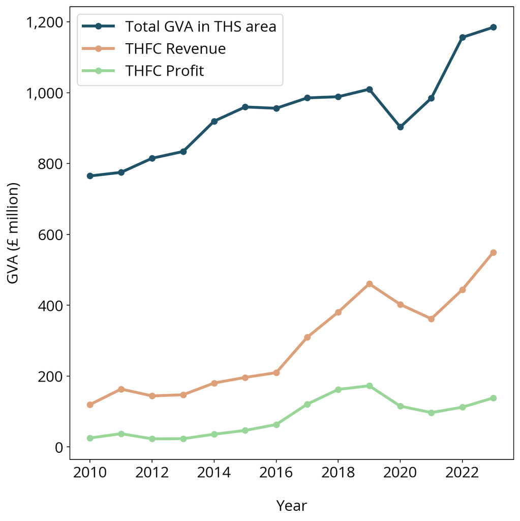

```python
lw = 3

fig, ax= plt.subplots(figsize=(8,8))

ax.plot(
    gva3['year'],
    gva3['gva'],
    label='Total GVA in THS area',
    color=jk_colours[0],
    linewidth=lw,
    marker='o'
)

ax.plot(
    ths_profit['year'],
    ths_profit['ths_revenue'],
    label='THFC Revenue',
    color=jk_colours[2],
    linewidth=lw,
    marker='o'
)

ax.plot(
    ths_profit['year'],
    ths_profit['ths_profit_before_exc'],
    label='THFC Profit',
    color=jk_colours[1],
    linewidth=lw,
    marker='o'
)

ax.set_ylabel('GVA (£ million)')
ax.set_xlabel('Year', labelpad=20)
# ax.set_title('Combined GVA of MSOAs in the 1km area around THS*')
msoas = ", ".join(intersecting_msoas_list)


ax.legend()
ax.set_xticks(np.arange(2010,2024,2));
ax.get_yaxis().set_major_formatter(
    mpl.ticker.FuncFormatter(lambda x, p: format(int(x), ',')))

plt.tight_layout()

fig.savefig(os.path.join('..','outputs','gva_revenue_profit.png'), dpi=300, bbox_inches='tight')
```

Now plot GVA growth with and without THFC revenue/profit, as well as GVA for other Haringey MSOAs

```
Loading data
```

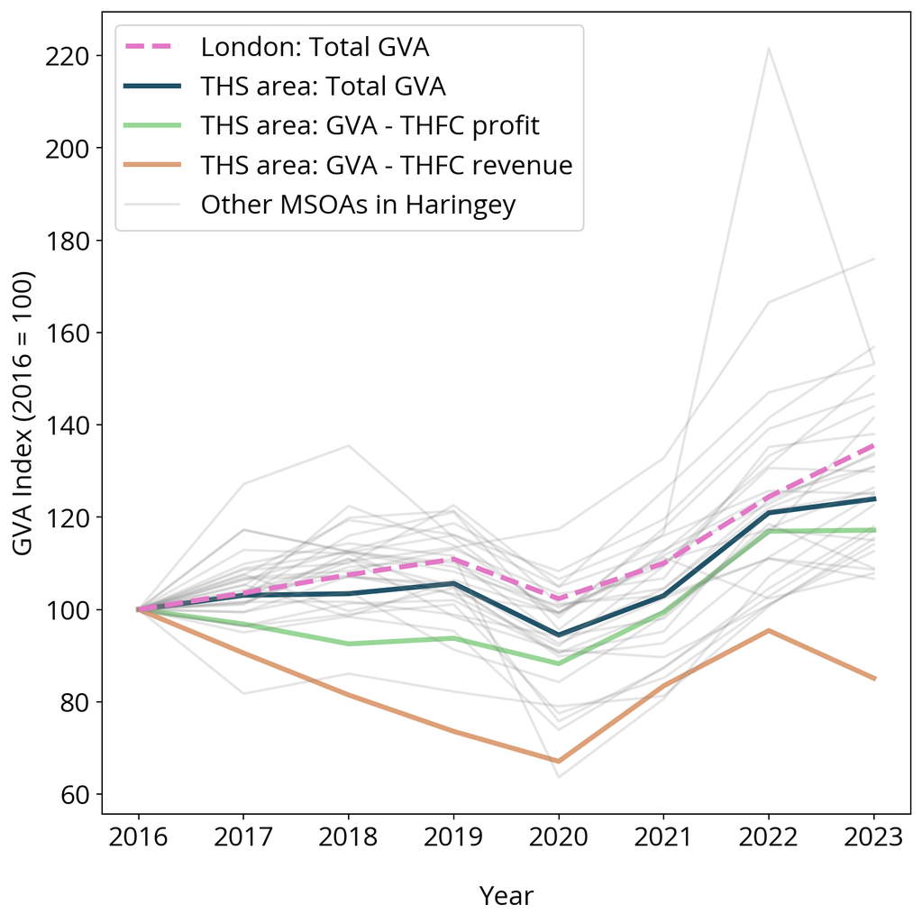

```python
base_year = 2016 # change this for a different base year from which to define growth. In report we also did 2018

# Convert to an index
vars_of_interest = ['gva','adjusted_gva_profit2', 'adjusted_gva_revenue']

gva_indexed = gva3[['year'] + vars_of_interest].copy()

gva_indexed = gva_indexed.loc[gva_indexed['year']>=base_year]

for var in vars_of_interest:
    base_value = gva_indexed.loc[gva_indexed['year']==base_year, var].iloc[0]
    gva_indexed[var + '_index'] = gva_indexed[var].div(base_value) * 100

# other areas
other_areas = gva_msoa.loc[~gva_msoa['msoa11cd'].isin(intersecting_msoas_list)]

# There was confusion but remember intersecting mosas contains 2 areas from enfield
# any(item in other_areas.msoa11cd.unique().tolist() for item in intersecting_msoas_list)
# any(item in intersecting_msoas_list for item in other_areas.msoa11cd.unique().tolist())
other_areas = other_areas.loc[(other_areas['year'] >= base_year) & (other_areas['year'] <= 2023)]

other_areas_indexed = other_areas.copy()

# Create a new column for the index
other_areas_indexed['gva_index'] = None

for msoa, group in other_areas_indexed.groupby('msoa11cd'):
    # Get base year value for this MSOA (in 2010)
    base = group.loc[group['year'] == base_year, 'gva']

    base_value = base.iloc[0]
    # Assign the indexed values back only for this MSOA
    other_areas_indexed.loc[group.index, 'gva_index'] = group['gva'] / base_value * 100

# Lodnon GVA
# Endpoint
base = "https://www.nomisweb.co.uk/api/v01/dataset/NM_2400_1.data.csv?"
# Type of measure (value/percent)
measures = "measures=20100"

cell = "cell=0"

# London
geography = 'geography=E12000007'

# Build the query
query = base + geography + "&" + cell + "&" + measures

data_dir = os.path.join('..','data')
filepath = os.path.join(data_dir, 'gva_london.csv')
if not os.path.isfile(filepath):
    response = requests.get(query)
    with open(filepath, 'wb') as file:
        file.write(response.content)
else:
    print('Loading data')

gva_london = pd.read_csv(filepath)

gva_london = janitor.clean_names(gva_london)

gva_london = gva_london.rename(
    columns = {
        'date': 'year',
        'obs_value': 'gva'

    }
)

gva_london = gva_london[['year','gva']]

gva_london = gva_london.loc[(gva_london['year'] >= base_year) & (gva_london['year'] <= 2023)]

gva_london_indexed = gva_london.copy()

# Create a new column for the index
gva_london_indexed['gva_index'] = None

# Get base year value for this MSOA (in 2010)
base_value = gva_london_indexed.loc[gva_london_indexed['year'] == base_year, 'gva'].iloc[0]

# Assign the indexed values back only for this MSOA
gva_london_indexed['gva_index'] = gva_london_indexed['gva'] / base_value * 100

# Plot
fig, ax = plt.subplots(figsize=(8,8))

lw = 3

ax.plot(
    gva_indexed['year'],
    gva_indexed['gva_index'],
    label='THS area: Total GVA',
    color=jk_colours[0],
    linewidth=lw
)

ax.plot(
    gva_indexed['year'],
    gva_indexed['adjusted_gva_profit2_index'],
    label='THS area: GVA - THFC profit',
    color=jk_colours[1],
    linewidth=lw
)

ax.plot(
    gva_indexed['year'],
    gva_indexed['adjusted_gva_revenue_index'],
    label='THS area: GVA - THFC revenue',
    color=jk_colours[2],
    linewidth=lw
)

# plot other msoas in haringey
for i, (_, group) in enumerate(other_areas_indexed.groupby('msoa11cd')):
    ax.plot(
        group['year'],
        group['gva_index'],
        label='Other MSOAs in Haringey' if i==0 else None,
        color='grey',
        alpha=0.2
    )

# plot London
ax.plot(
    gva_london_indexed['year'],
    gva_london_indexed['gva_index'],
    label='London: Total GVA',
    color=jk_colours[3],
    linewidth=lw,
    linestyle='dashed'
)


ax.set_ylabel(f'GVA Index ({base_year} = 100)')
ax.set_xlabel('Year', labelpad=20)
# ax.set_title('Combined GVA of MSOAs in the 1km area around THS*')
msoas = ", ".join(intersecting_msoas_list)

# Get current handles and labels
handles, labels = ax.get_legend_handles_labels()

# Define your preferred order (by label name)
if base_year == 2016:
    order = [
        'London: Total GVA',
        'THS area: Total GVA',
        'THS area: GVA - THFC profit',
        'THS area: GVA - THFC revenue',
        'Other MSOAs in Haringey'
    ]
elif base_year == 2018:
    order = [
        'THS area: GVA - THFC profit',
        'London: Total GVA',
        'THS area: Total GVA',
        'THS area: GVA - THFC revenue',
        'Other MSOAs in Haringey'

    ]

# Apply the order (filtering in case some labels don’t exist)
handles = [h for _, h in sorted(zip(labels, handles), key=lambda x: order.index(x[0])) if _ in order]
labels = [l for l in order if l in labels]

# Plot legend in the new order
ax.legend(handles, labels)

ax.set_xticks(np.arange(base_year,2024,1));

plt.tight_layout()

fig.savefig(os.path.join('..','outputs','gva_index_base' + str(base_year) + '.png'), dpi=300, bbox_inches='tight')
```

This plot is just GVA (i.e. it’s not indexed to a base year)

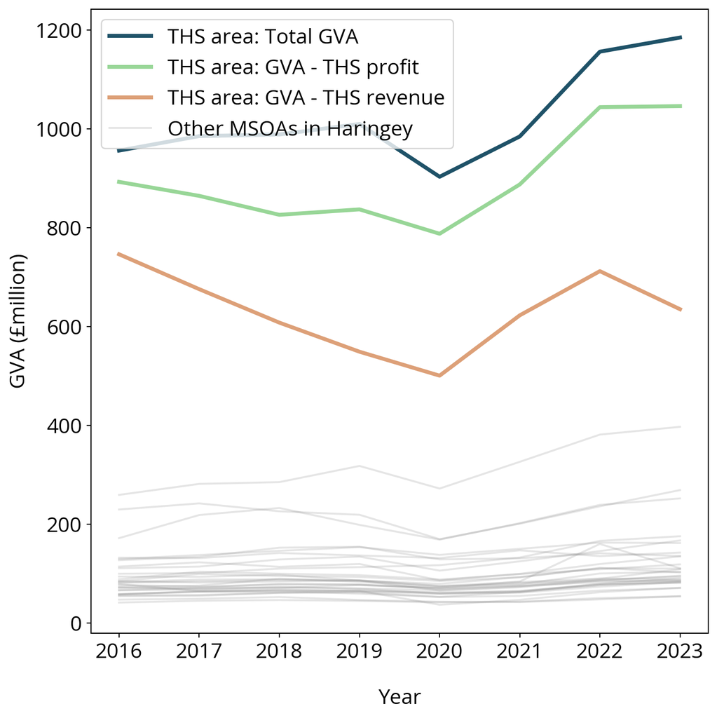

```python
fig, ax = plt.subplots(figsize=(8,8))

lw = 3

ax.plot(
    gva_indexed['year'],
    gva_indexed['gva'],
    label='THS area: Total GVA',
    color=jk_colours[0],
    linewidth=lw
)

ax.plot(
    gva_indexed['year'],
    gva_indexed['adjusted_gva_profit2'],
    label='THS area: GVA - THS profit',
    color=jk_colours[1],
    linewidth=lw
)

ax.plot(
    gva_indexed['year'],
    gva_indexed['adjusted_gva_revenue'],
    label='THS area: GVA - THS revenue',
    color=jk_colours[2],
    linewidth=lw
)

# plot other msoas in haringey
for i, (_, group) in enumerate(other_areas_indexed.groupby('msoa11cd')):
    ax.plot(
        group['year'],
        group['gva'],
        label='Other MSOAs in Haringey' if i==0 else None,
        color='grey',
        alpha=0.2
    )

ax.set_ylabel(f'GVA (£million)')
ax.set_xlabel('Year', labelpad=20)
# ax.set_title('Combined GVA of MSOAs in the 1km area around THS*')
msoas = ", ".join(intersecting_msoas_list)



ax.legend()
ax.set_xticks(np.arange(base_year,2024,1));

plt.tight_layout()

fig.savefig(os.path.join('..','outputs','gva_base' + str(base_year) + '.png'), dpi=300, bbox_inches='tight')
```

Plot the map of the nine areas included in the 1km buffer zone, highlighting THS.

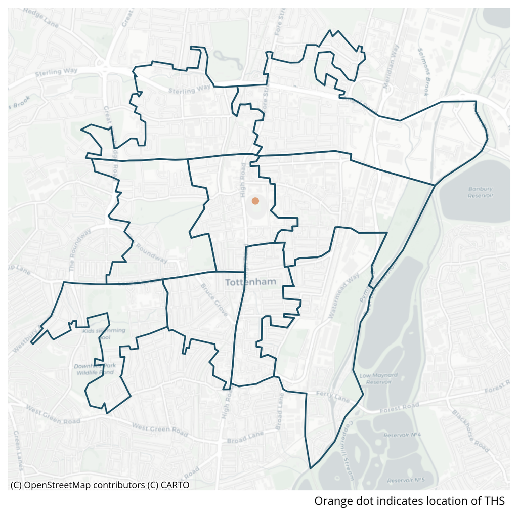

```python
import contextily as cx
fig, ax1 = plt.subplots(figsize=(8,8))
intersecting_msoas_gdf.boundary.plot(ax=ax1, edgecolor=jk_colours[0])

tott.plot(ax=ax1, marker='o', color=jk_colours[2], markersize=30)

cx.add_basemap(ax=ax1, crs=intersecting_msoas_gdf.crs, source=cx.providers.CartoDB.Positron)
ax1.annotate(
    xy=(0.99, -0.03),
    xycoords='axes fraction',
    text=f'Orange dot indicates location of THS',
    ha='right',
    size=10
)

ax1.set_axis_off()
# ax1.set_title('*MSOAs included within the 1km area around THS')
fig.savefig(os.path.join('..','outputs','ths_1km_msoas.png'), dpi=300, bbox_inches='tight')
```

For convenience, also plot THS’ location relative to Northumberland Park (for webinar slides)

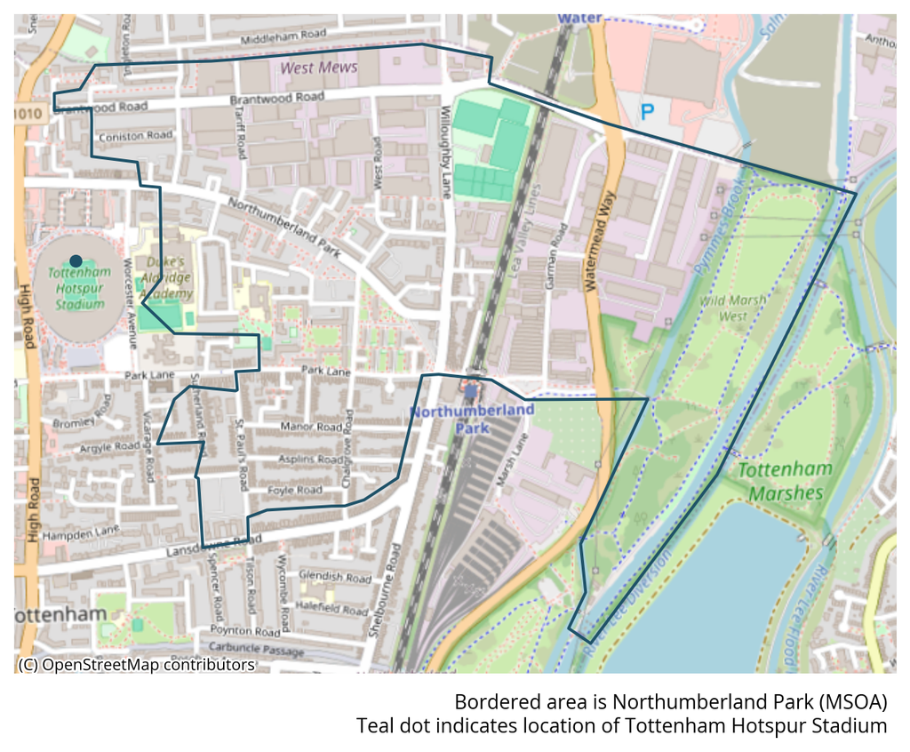

```python
np = intersecting_msoas_gdf.loc[intersecting_msoas_gdf['msoa11cd']=='E02000398']
fig, ax1 = plt.subplots(figsize=(8,8))
np.boundary.plot(ax=ax1, edgecolor=jk_colours[0])

tott.plot(ax=ax1, marker='o', color=jk_colours[0], markersize=30)

cx.add_basemap(ax=ax1, crs=np.crs, source=cx.providers.OpenStreetMap.Mapnik)
ax1.annotate(
    xy=(0.99, -0.03),
    xycoords='axes fraction',
    text=f'Bordered area is Northumberland Park (MSOA)\nTeal dot indicates location of Tottenham Hotspur Stadium',
    va='top',
    ha='right',
    size=10
)

ax1.set_axis_off()
# ax1.set_title('*MSOAs included within the 1km area around THS')
fig.savefig(os.path.join('..','outputs','ths_np.png'), dpi=300, bbox_inches='tight')
```